# Ladok Resultat

2017-10-26

## Registrerade studenter

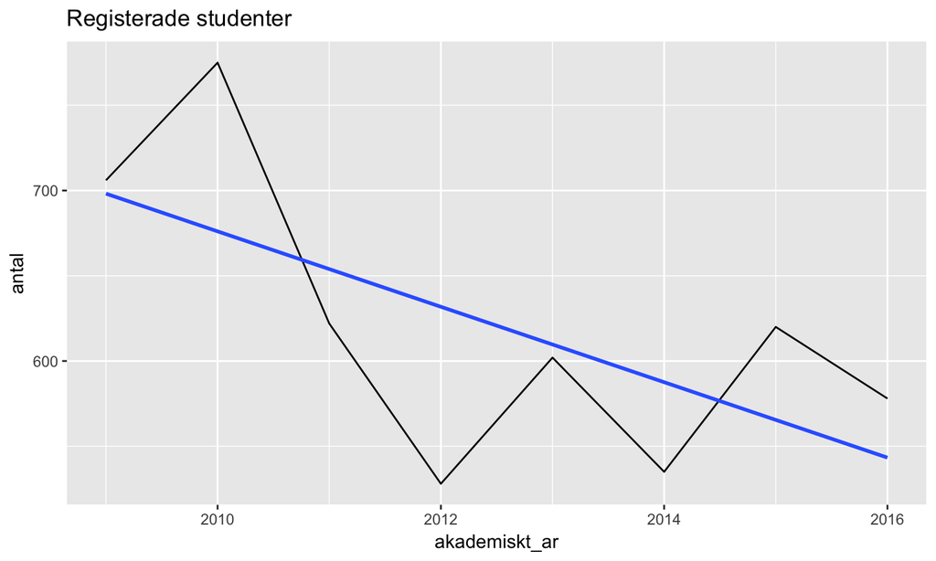

## Studenter per kurs

Andelen som läser på A nivå minskar sakta över tiden.

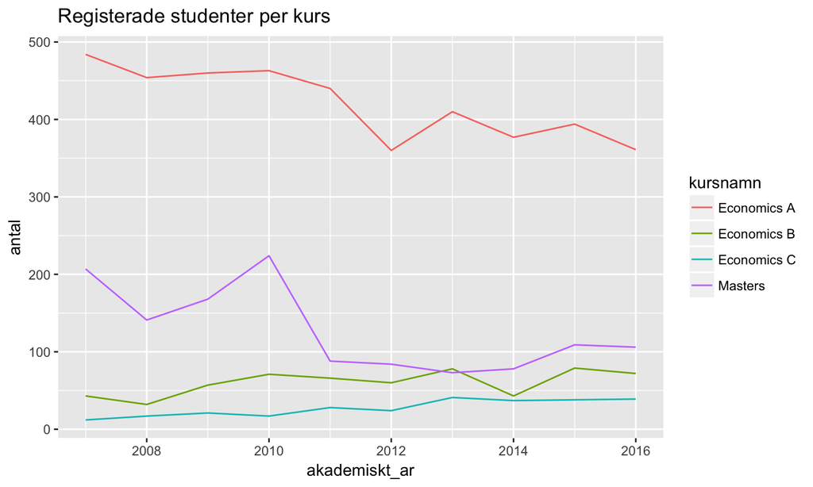

## Programstudenter

Andelen programstudenter har minskat. Fler läser enstaka kurs.

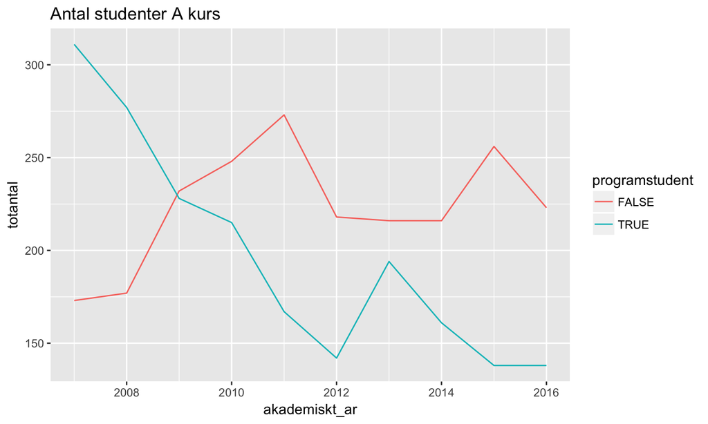

## Olika program

## Programstudenter

Andelen programstudenter har minskat. Fler läser enstaka kurs.

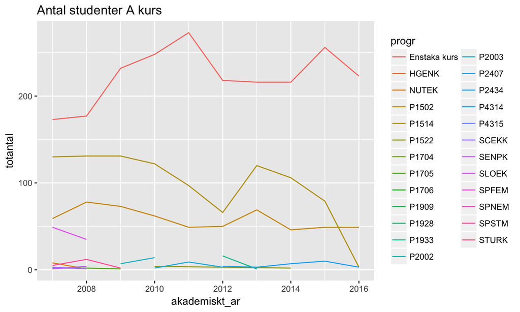

## Studietid

Det tar lång tid att läsa.

Notera att det finns 252 studenter med slutdatum (idatum i godkkurs) före startdatum (idatum i ffgkurs)

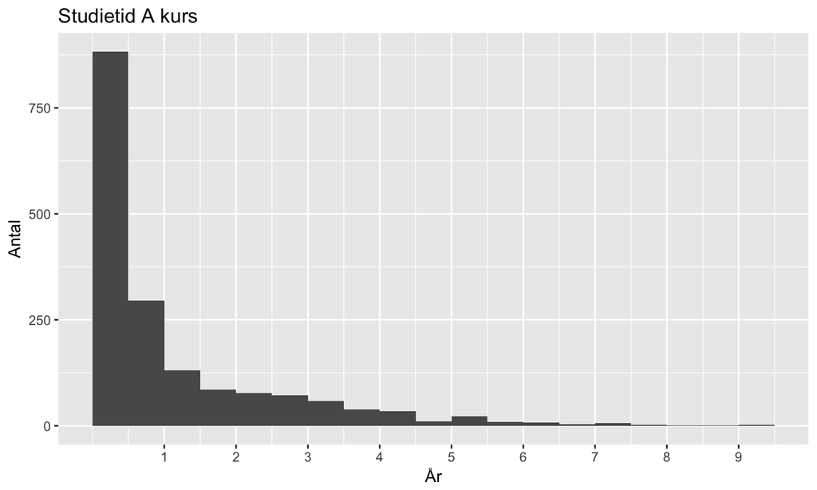

## Nollpresterare

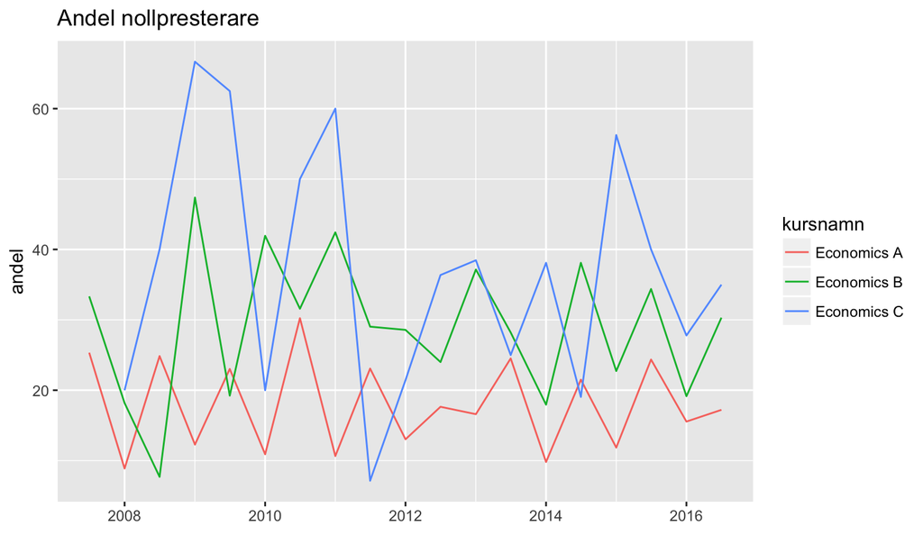

## Economics A - Kursresultat

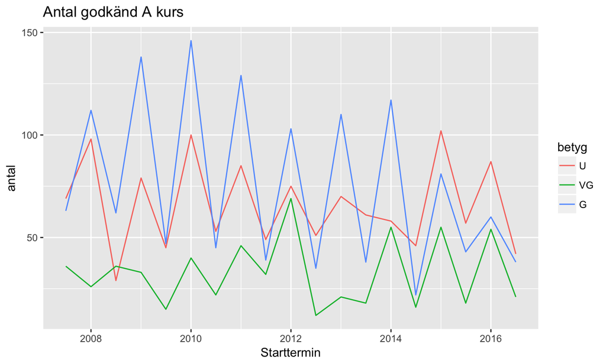

## Economics A - Andelar

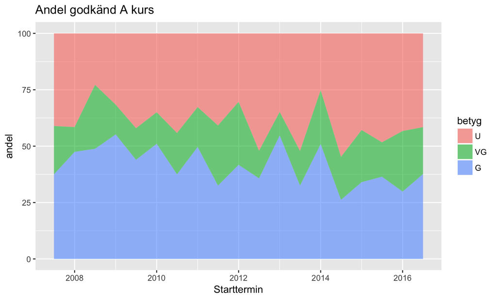

## Programstudenter

Även för programstudenter minskar andelen godkända de senaste åren.

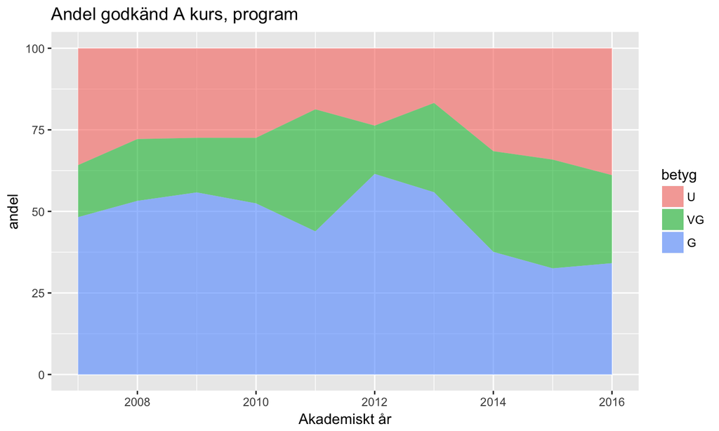

## Enstaka kurs studenter

För studenter som läser enstaka kurs minskar andelen godkända över hela perioden.

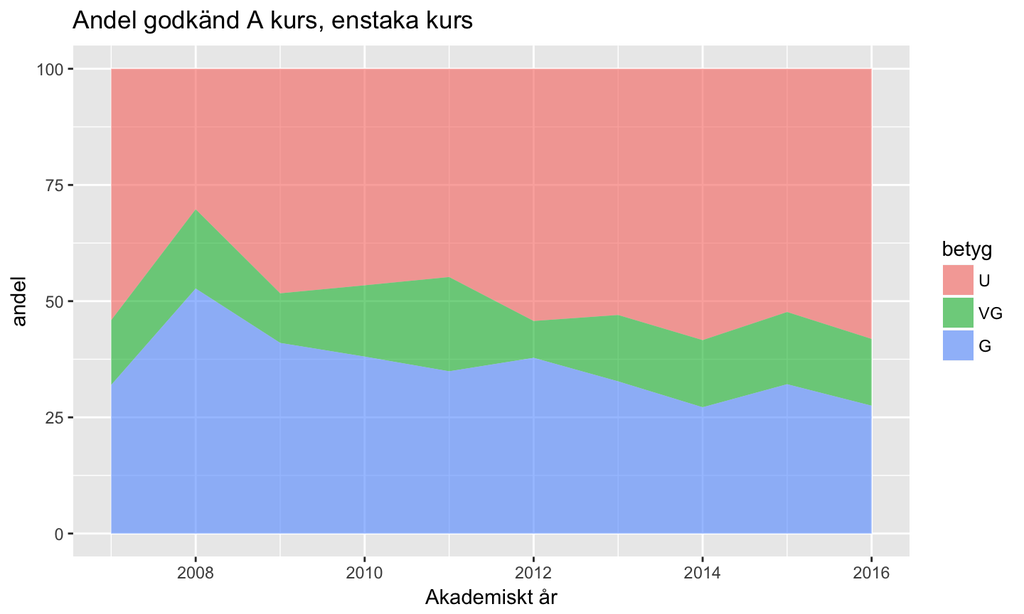

## Kön

- Män klarar studier sämre

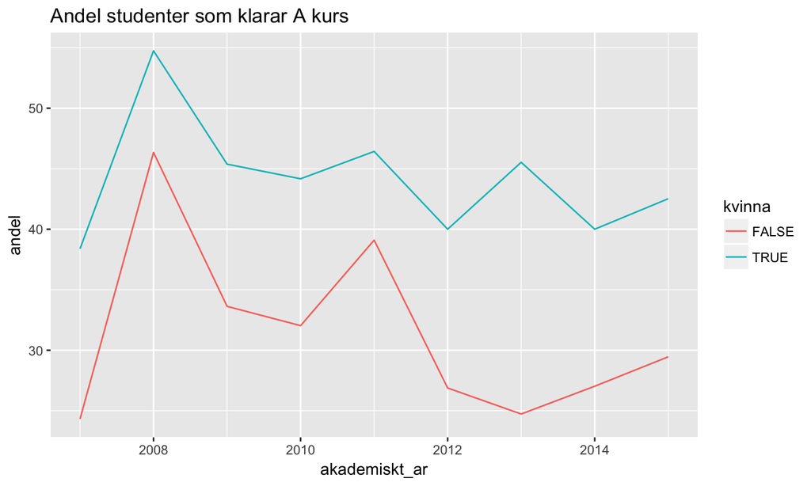

## Economics B - Kursresultat

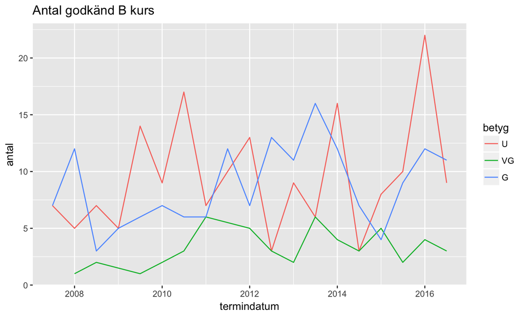

## Economics B - Andelar

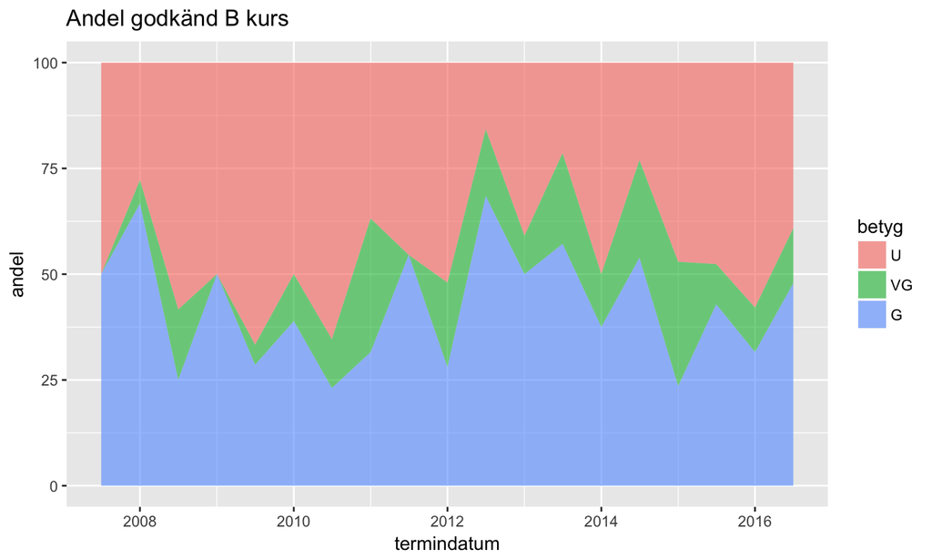

## Economics C - Kursresultat

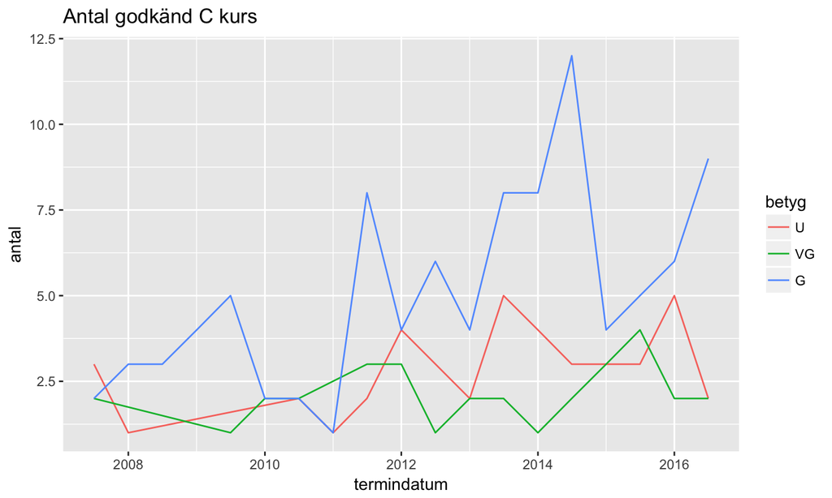

## Economics C - Andelar

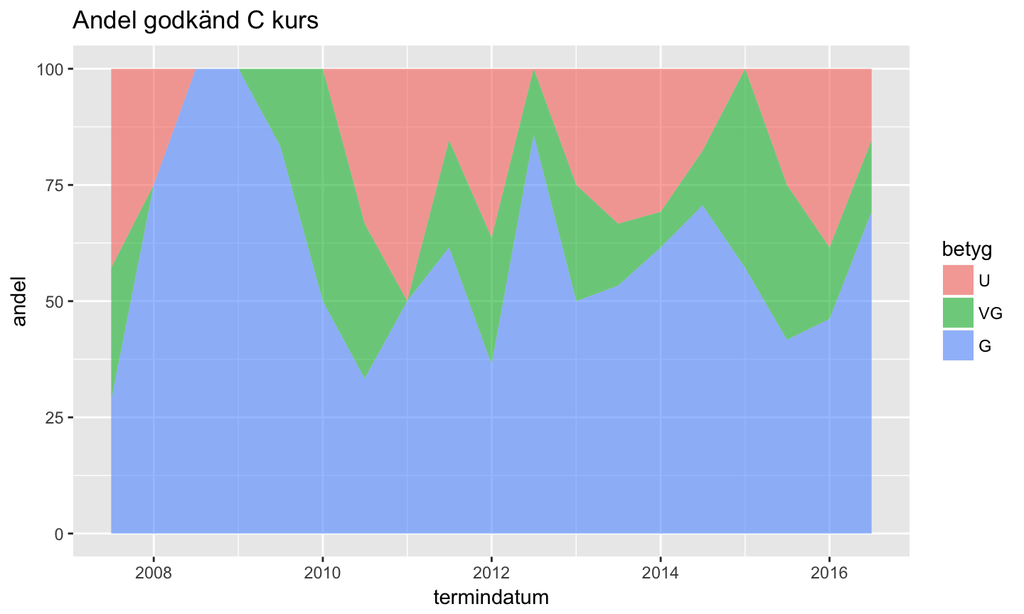

## Uppsats

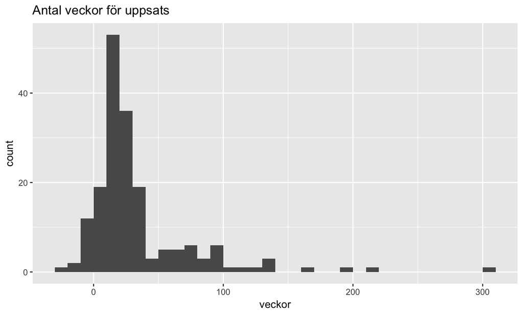

För 19.4 procent av studenterna tog det mer än ett år att bli färdig.

## Vad saknas för de studenter som inte är klara med A kursen?

Totalt var 422 inte godkända på A kursen. Per delkurs var det:

| delkurs | n |
| --- | --- |
| Applied Macroeconomics | 228 |
| Applied Microeconomics and Trade Theory | 160 |
| Macroeconomics | 290 |
| Microeconomics | 218 |

## Hur många delkurser har de läst?

| delkursantal | Enstaka kurs | Program | Totalt | andel |
| --- | --- | --- | --- | --- |
| 0 | 95 | 22 | 117 | 27.7 |
| 1 | 45 | 13 | 58 | 13.7 |
| 2 | 31 | 11 | 42 | 10.0 |
| 3 | 46 | 20 | 66 | 15.6 |
| 4 | 91 | 48 | 139 | 32.9 |

## Vilken kurs saknas för de som har en kurs kvar?

| delkurs | n |
| --- | --- |
| Applied Macroeconomics | 4 |
| Applied Microeconomics and Trade Theory | 23 |
| Macroeconomics | 1 |
| Microeconomics | 4 |

## Demografiska variabler

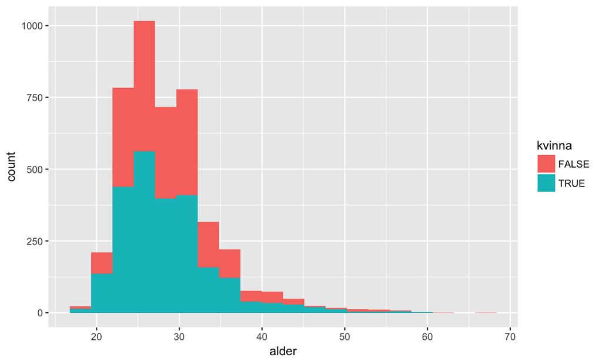

## Vilka B/C kurser läser studenter?

Totalt 3468 godkända studenter. Antal godkända per kurs under akademiska åren 2015 och 2016.

| delkurs | Economics B | Economics C | Totalt |
| --- | --- | --- | --- |
| Intermediate Macroeconomics | 43 | 30 | 73 |
| Intermediate Microeconomics | 52 | 13 | 65 |
| Essay | 0 | 61 | 61 |
| Econometrics | 22 | 32 | 54 |
| International Trade Theory | 44 | 3 | 47 |
| Development Economics | 43 | 2 | 45 |
| Environmental Economics | 40 | 3 | 43 |
| Corporate Governance | 28 | 10 | 38 |
| Financial Economics | 23 | 6 | 29 |
| Industrial Organisation | 26 | 2 | 28 |
| Public Finance | 9 | 1 | 10 |
| Social Choice | 4 | 3 | 7 |
| Socio-Economic Institutions | 5 | 0 | 5 |
| Health Economics | 0 | 1 | 1 |